# Praca domowa 8

Ola Paluszynska

15 maja 2017

# Cel pracy

Celem naszej pracy jest zapoznanie się z rozkładami oszacowań efektów stałych i losowych modelu mieszanego szacowanego na zbiorze danych `lme4::sleepstudy` ze zmienną objaśnianą powstałą przez wylosowanie odpowiednich efektów losowych z rozkładu normalnego o ustalonych parametrach, których wartości chcemy odtworzyć za pomocą estymacji.

## Dane

Struktura wykorzystywanego zbioru danych jest następująca:

```r
library(lme4)
library(ggplot2)
library(moments)
head(sleepstudy)
```

```
##   Reaction Days Subject
## 1 249.5600    0     308
## 2 258.7047    1     308
## 3 250.8006    2     308
## 4 321.4398    3     308
## 5 356.8519    4     308
## 6 414.6901    5     308
```

```r
str(sleepstudy)
```

```
## 'data.frame':    180 obs. of  3 variables:
##  $ Reaction: num  250 259 251 321 357 ...
##  $ Days    : num  0 1 2 3 4 5 6 7 8 9 ...
##  $ Subject : Factor w/ 18 levels "308","309","310",..: 1 1 1 1 1 1 1 1 1 1 ...
```

## Prawdziwe wartości parametrów

Ustalamy prawdziwe wartości szacowanych parametrów (specjalnie wybieramy wszystkie wariancje takie same, podobnie efekty stałe, żeby móc porównywać między sobą rozkłady ich oszacowań):

```r
sigma <- 2 # odchylenie standardowe epsilona
sigma_i <- 2 # odchylenie standardowe interceptów
sigma_s <- 2 # odchylenie standardowe slope'ów
intercept0 <- 4 # stała w modelu
slope0 <- 4 # nachylenie (efekt stały)
```

## Rozkład oszacowań

### Parametry symulacji

W symulacjach będziemy wykorzystywać następujące parametry:

```r
p <- length(unique(sleepstudy$Subject)) # liczba obiektów
n <- nrow(sleepstudy) # liczba obserwacji
r <- 1000 # liczba symulacji
```

### Symulacje

Teraz wykonamy 1000 symulacji, za każdym razem zapisując efekty stałe, wariancje efektów losowych i wariancję składnika losowego.

```r
set.seed(2017)
wynik <- replicate(r, {
  data <- merge(data.frame(Subject = unique(sleepstudy$Subject), intercepts = rnorm(p, 0, sigma_i),
                               slopes = rnorm(p, 0, sigma_s)), data.frame(sleepstudy, errors = rnorm(n, 0, sigma)))
  data$y <- intercept0 + data$intercepts + (slope0 + data$slopes) * data$Days + data$errors
  modelSim <- lmer(y ~ 1 + Days + (1 | Subject) + (Days - 1 | Subject), data = data)
  c(t(summary(modelSim)$coefficients[, 1]), unlist(summary(modelSim)$varcor), summary(modelSim)$sigma^2)
})
wynik <- as.data.frame(t(wynik))
colnames(wynik) <- c("intercept0", "slope0", "sigma_i_squared", "sigma_s_squared", "sigma_squared")
```

Teraz przedstawimy rozkłady odpowiednich wartości na histogramach, gdzie prawdziwe wartości parametrów oznaczymy czerwoną linią, a średnie rozkładu empirycznego niebieskimi liniami przerywanymi.

### Rozkład oszacowań efektów stałych

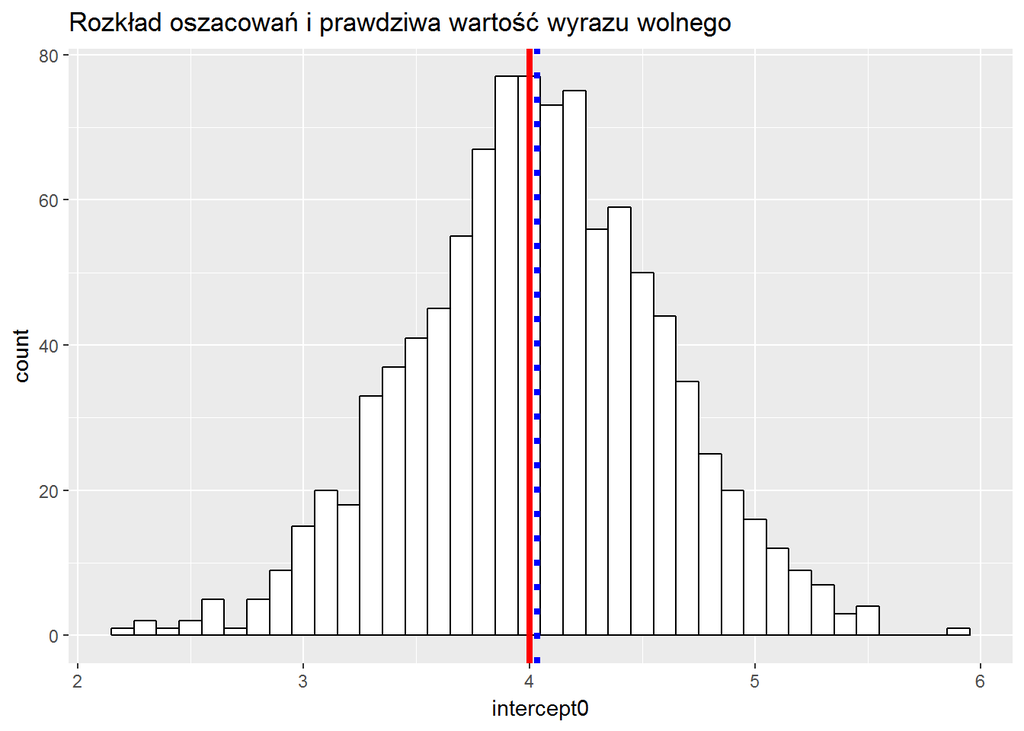

```r
ggplot(wynik, aes(x = intercept0)) + geom_histogram(binwidth = 0.1, color = "black", fill = "white") + geom_vline(xintercept = intercept0, size = 1.5, color = "red") + ggtitle("Rozkład oszacowań i prawdziwa wartość wyrazu wolnego") + geom_vline(xintercept = mean(wynik$intercept0), size = 1.5, color = "blue", lty = 3)
```

Przedstawiony poniżej rozkład oszacowań nachylenia wygląda bardzo podobnie do rozkładu oszacowań wyrazu wolnego (skośność: -0.0394261, kurtoza: -0.001460069).

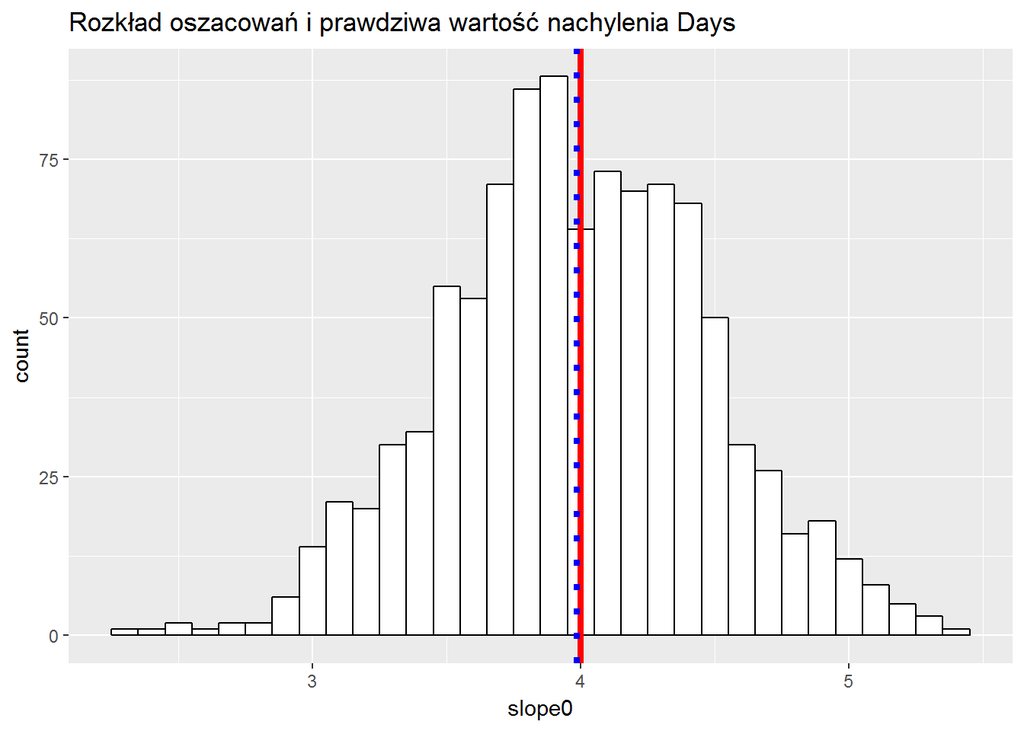

```r
ggplot(wynik, aes(x = slope0)) + geom_histogram(binwidth = 0.1, color = "black", fill = "white") + geom_vline(xintercept = slope0, size = 1.5, color = "red") + ggtitle("Rozkład oszacowań i prawdziwa wartość nachylenia Days") + geom_vline(xintercept = mean(wynik$slope0), size = 1.5, color = "blue", lty = 3)
```

### Rozkład oszacowań wariancji

Na poniższym wykresie widać rozkład oszacowań wariancji błędu (epsilona) modelu – ogólnie rozkład ten jest dość skoncentrowany wokół prawdziwej wartości.

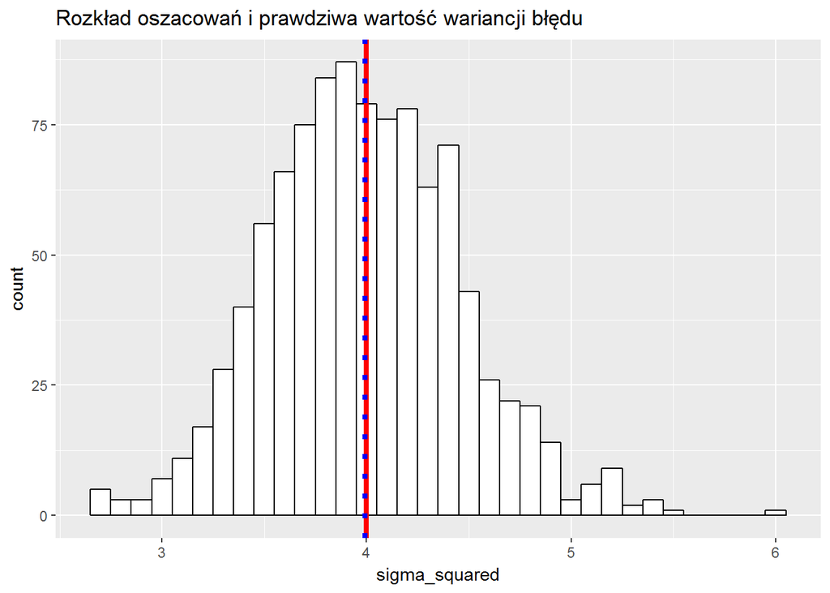

```r
ggplot(wynik, aes(x = sigma_squared)) + geom_histogram(binwidth = 0.1, color = "black", fill = "white") + geom_vline(xintercept = sigma^2, size = 1.5, color = "red") + ggtitle("Rozkład oszacowań i prawdziwa wartość wariancji błędu") + geom_vline(xintercept = mean(wynik$sigma_squared), size = 1.5, color = "blue", lty = 3)
```

W przypadku wariancji efektu losowego związanego z wyrazem wolnym rozkład oszacowań (poniżej) jest mniej skoncentrowany wokół prawdziwej wartości, w dodatku wygląda na bimodalny i ma dość długi prawy ogon.

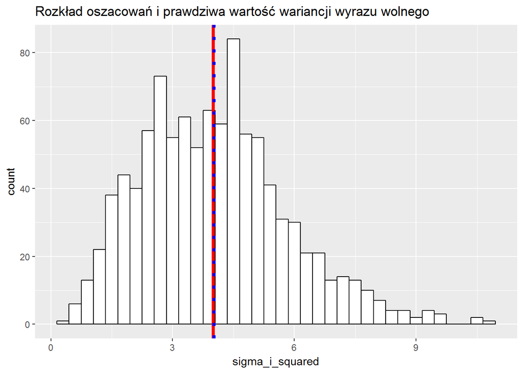

```r
ggplot(wynik, aes(x = sigma_i_squared)) + geom_histogram(binwidth = 0.3, color = "black", fill = "white") + geom_vline(xintercept = sigma_i^2, size = 1.5, color = "red") + ggtitle("Rozkład oszacowań i prawdziwa wartość wariancji wyrazu wolnego") + geom_vline(xintercept = mean(wynik$sigma_i_squared), size = 1.5, color = "blue", lty = 3)
```

Rozkład oszacowań wariancji efektu losowego nachylenia wygląda niemalże identycznie do poprzedniego.

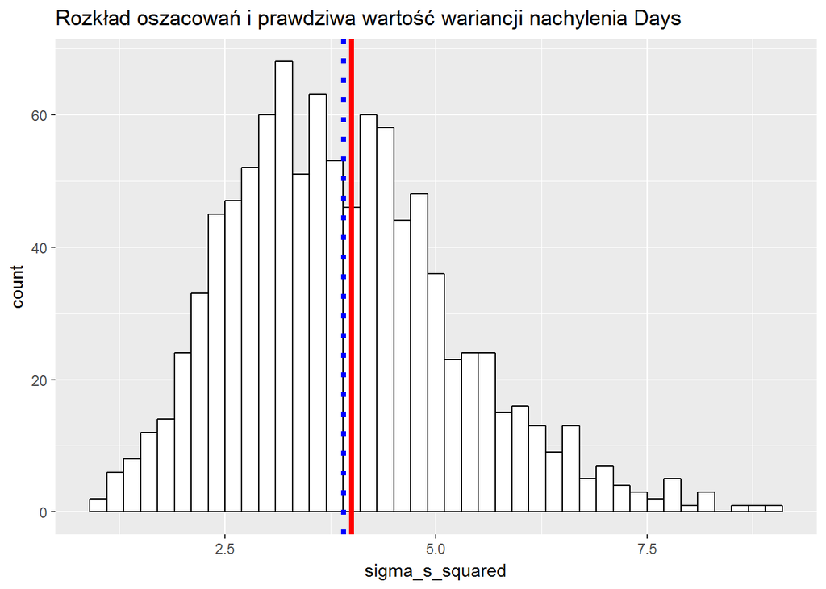

```r
ggplot(wynik, aes(x = sigma_s_squared)) + geom_histogram(binwidth = 0.2, color = "black", fill = "white") + geom_vline(xintercept = sigma_s^2, size = 1.5, color = "red") + ggtitle("Rozkład oszacowań i prawdziwa wartość wariancji nachylenia Days") + geom_vline(xintercept = mean(wynik$sigma_s_squared), size = 1.5, color = "blue", lty = 3)
```